# convenience Heatmap

## Introduction

cHeatmap is a wrapper of the excellent [`ComplexHeatmap::Heatmap()`](https://jokergoo.github.io/ComplexHeatmap/reference/Heatmap.html) function with additional functions and more friendly interface for some common tasks in my work, thus called the **c**onvenience **Heatmap**. I highly recommend reading the [ComplexHeatmap book](https://jokergoo.github.io/ComplexHeatmap-reference/book/index.html) for more advanced use.

Here are the features:

1. Automatic or manual setting of the values of outliers in the input matrix so that the color scale of the heatmap is not dominated by those outliers
2. The option to set the color-value mappings in the heatmap legend
3. Automatic coloring of the dendrogram
4. Easy highlight or display of the values of certain cells
5. Discrete color-value mapping for integer matrices containing few unique values
6. Clustering of the character matrix based on the orders of characters
7. Interface to plot across rows
8. Handling of edge cases:
- Inf and -Inf values in input matrix cause errors in `stats::dist()` for clustering, they are reset as NA.
- If missing values are present in the input matrix or row and column annotations, a legend for missing value is added.

## Examples

### Reset the value of outliers

Outliers in a numeric matrix dominate the color scale and make the differences among many cells barely visible, such as `nMat1` below.

```
{r setup, include = FALSE, echo = FALSE}
knitr::opts_chunk$set(
  collapse = TRUE,
  comment = "#>",
  tidy = TRUE
)
```

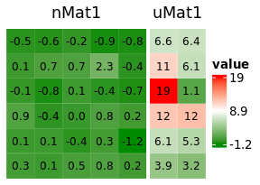

```r
library(cHeatmap)

set.seed(100)
nMat1 <- rnorm(30)
uMat1 <- runif(12, -5, 20)
mat1 <- matrix(c(nMat1, uMat1), nrow = 6)

cHeatmap(mat1,
  name = "value", # legend title
  resetOutliers = F, # do not detect outliers
  cluster_rows = F, cluster_columns = F, # no clustering
  cellFun = function(x) { x }, # display all the values
  column_split = c(rep("nMat1", 5), rep("uMat1", 2)) # mark the two matrices
)
```

Set `resetOutliers = T` to detect outliers in `mat1` and reset their values, so that the difference in the values of `nMat1` can be easily visualized. See [Reference Manual](https://blueskypie.github.io/cHeatmap/reference/cHeatmap.html) for details. Note that the upper label of the legend changes to `>6.6`.

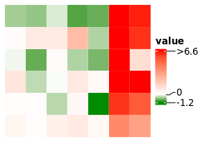

```r
cHeatmap(mat1,
  name = "value",
  resetOutliers = T,
  cluster_rows = F, cluster_columns = F,
  whiteValue = 0 # set the white values in the legend to 0
)
```

Instead of auto-detecting the outliers, use the `colMap` to set the range. Values outside of the range are outliers. The default of `colMap` is `c("green4"=NA, "white"=whiteValue, "red"=NA)`.

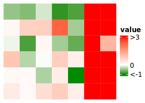

```r
cHeatmap(mat1,
  name = "value",
  resetOutliers = F,
  cluster_rows = F, cluster_columns = F,
  colMap = c(-1, 0, 3)
)
```

Only set the upper bound, auto-detect the lower bound.

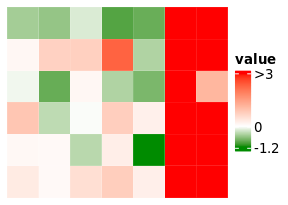

```r
cHeatmap(mat1,
  name = "value",
  resetOutliers = T,
  cluster_rows = F, cluster_columns = F,
  colMap = c(NA, 0, 3)
)
```

### Manually set the color-value mapping

Set colors and also the value for the middle color.

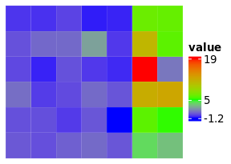

```r
cHeatmap(mat1,
  name = "value",
  resetOutliers = F,
  cluster_rows = F, cluster_columns = F,
  colMap = c("blue" = NA, "green" = 5, "red" = NA)
)
```

Set the upper and lower bounds.

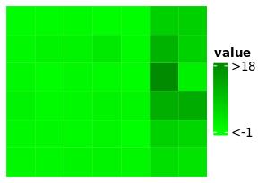

```r
cHeatmap(mat1,
  name = "value",
  resetOutliers = F,
  cluster_rows = F, cluster_columns = F,
  colMap = c("green" = -1, "green4" = 18)
)
```

Set multiple color-value mappings to visualize both global and local differences, for example, if the matrix contains two distant clusters - `nMat1` and `uMat1`.

Also note that `Inf` is reset to `NA` to avoid error in clustering and a legend for missing values is added automatically.

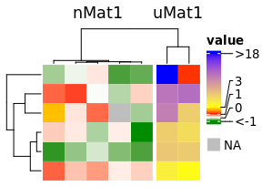

```r
# create an Inf value
mat2=mat1
mat2[2,2]=Inf

cHeatmap(mat2,
  name = "value",
  resetOutliers = F,
  colMap = c("green4" = -1, "white" = 0, "red" = 1, #cluster 1
             "yellow" = 3, "blue" = 18), #cluster 2
  column_split = c(rep("nMat1", 5), rep("uMat1", 2))
)
```

```r
rm(mat2)
```

Adjust the legend to

- lengthen the portion for cluster 1
- shorten the portion between 1 and 3 if majority of cluster 2 are in (3, 18)
- increase the height of the whole legend to 4cm

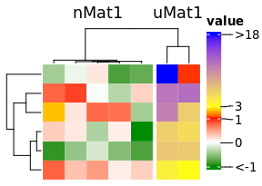

```r
cHeatmap(mat1,
  name = "value",
  resetOutliers = F,
  colMap = c("green4" = -1, "white" = 0, "red" = 1, #cluster 1
             "yellow" = 3, "blue" = 18), #cluster 2
  column_split = c(rep("nMat1", 5), rep("uMat1", 2)),
  legendBreakDist = c(1, 1, 0.5, 3),
  legendHeight = 4
)
```

Set distinct color to different numerical ranges

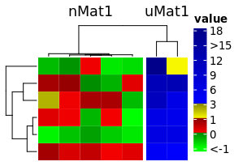

```r
lt=c(-1,0,1,3,6,9,12,15,18)
cHeatmap(mat1,
         name = "value",
         resetOutliers = F,
         colMap = c(
           green = -1, green4 = 0,
           red = 10e-6, red4=1,
           yellow=1+10e-6,yellow4 = 3,
           blue=3+10e-6, blue4 = 18),
         legendTicks = lt,
         legendBreakDist = rep.int(1,length(lt)-1),
         legendHeight = 4,
         column_split = c(rep("nMat1", 5), rep("uMat1", 2))
)
```

### Display cell values using `cellFun`

Show only values in (0.5, 1).

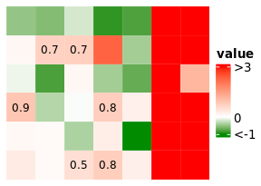

```r
cHeatmap(mat1,
  name = "value",
  resetOutliers = F,
  cluster_rows = F, cluster_columns = F,
  colMap = c(-1, 0, 3),
  cellFun = function(x) { if (x > 0.5 && x < 1) x }
)
```

Display only the outliers, e.g. those outside of the range of `colMap`.

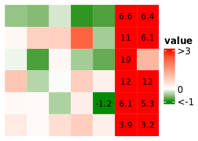

```r
cHeatmap(mat1,
  name = "value",
  resetOutliers = F,
  cluster_rows = F, cluster_columns = F,
  colMap = c(-1, 0, 3),
  cellFun = "o" # 'o' is hard-coded to represent outliers
)
```

Mark outliers as `*`; note by default `resetOutliers = TRUE` for numeric matrices.

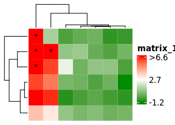

```r
cHeatmap(mat1, cellFun = c("o", "*"))
```

Color outliers by black edge.

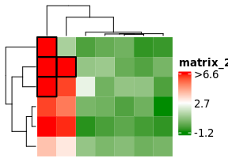

```r
cHeatmap(mat1,
  cellFun = c(
    "o", list("rect", col = "black", lwd = 2)
  )
)
```

Display `H` if cell values > 2 and `L` if < 0.

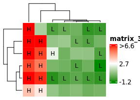

```r
cHeatmap(mat1,
  cellFun = function(x) {
    if (x > 2) {      "H"
    } else if (x < 0) "L"
  }
)
```

Add black edge if cell values > 2 and display `L` if < 0.

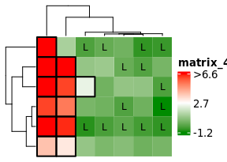

```r
cHeatmap(mat1,
  cellFun = function(x) {
    if (x > 2) {
      list("rect", col = "black", lwd = 2)
    } else if (x < 0) "L"
  }
)
```

### Color dendrograms and split the clusters

`nRowCluster` and `nColmCluster` specify the number of colors in the corresponding dendrograms.

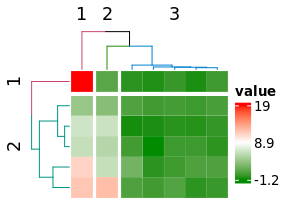

```r
cHeatmap(mat1,
  name = "value",
  resetOutliers = F,
  nRowCluster = 2, nColmCluster = 3,
  row_split = 2, column_split = 3
)
```

### Integer matrices

If the number of unique values is greater than `intAsDiscreteCutoff` whose default value is 6 in `cHeatmap` parameter settings, the color mapping is continuous; otherwise, the mapping is discrete.

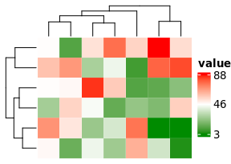

```r
mati <- matrix(sample(1:100, 42, TRUE), nrow = 6)
cHeatmap(mati, name = "value")
```

```r
mati <- matrix(sample(1:5, 42, TRUE), nrow = 6)
cHeatmap(mati, name = "value")
```

[output not shown]

Set colors manually and show numbers 1, 3, and 5.

```r
cHeatmap(mati,
  name = "value",
  colMap = c("red" = 1, "pink" = 2, "yellow" = 3, "green" = 4, "green4" = 5),
  cellFun = function(x) {
    if (x %in% c(1, 3, 5)) x
  }
)
```

[output not shown]

### Character matrices

```r
matc <- matrix(sample(letters[1:6], 42, TRUE), nrow = 6)
cHeatmap(matc, name = "value")
```

[output not shown]

Cluster the matrix by converting characters to their alphabetic orders, i.e. `a .. f` to `1 .. 6`, and manually set the color-value mappings.

```r
cHeatmap(matc,
  name = "value",
  nColmCluster = 3, nRowCluster = 2,
  colMap = c(
    "red" = "a", "pink" = "b", "yellow" = "c",
    "green" = "d", "green2" = "e", "green4" = "f"
  )
)
```

[output not shown]

### Row and column annotation

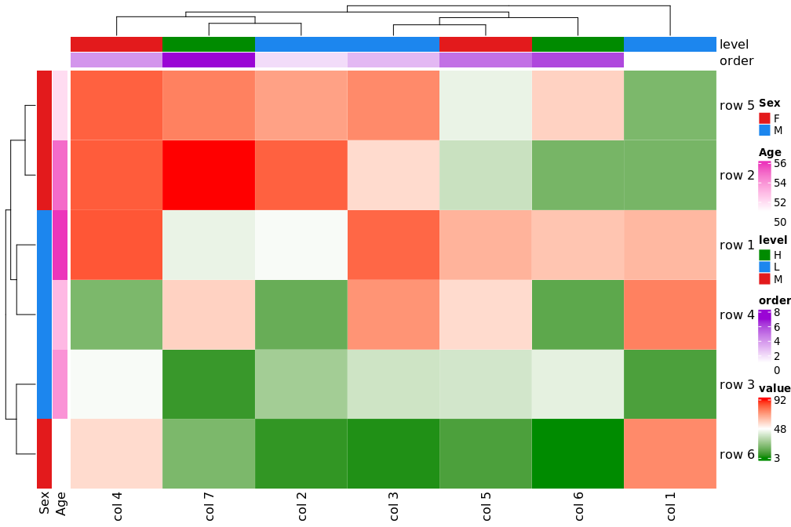

```r
# create the matrix ----
mat1 <- matrix(sample(1:100, 42, TRUE), nrow = 6)
rownames(mat1) <- paste("row", 1:6)
colnames(mat1) <- paste("col", 1:7)

# create the row annotation data frame ---
rowDf <- data.frame(Sex = c("F", "F", "M", "M", "F", "M"), Age = 51:56)
rownames(rowDf) <- paste("row", 6:1)

# create the column annotation data frame ---
colDf <- data.frame(level = c("H", "H", "M", "M", "L", "L", "L"), order = 7:1)
rownames(colDf) <- paste("col", 7:1)

# make sure the rows and columns of the annotation data frame are at the same
#   order as those of mat1
stopifnot(all(rownames(mat1) %in% rownames(rowDf)) && nrow(mat1) == nrow(rowDf))
rowDf <- rowDf[rownames(mat1), ]
stopifnot(all(colnames(mat1) %in% rownames(colDf)) && ncol(mat1) == nrow(colDf))
colDf <- colDf[colnames(mat1), ]

cHeatmap(mat1, name = "value", rowAnnoDf = rowDf, colmAnnoDf = colDf)
```

Set some annotation colors manually.

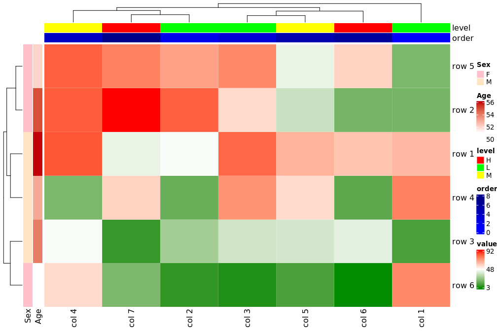

```r
cHeatmap(mat1,
  name = "value",
  rowAnnoDf = rowDf, colmAnnoDf = colDf,
  rowAnnoColMap = list(Sex = c("pink" = "F", "bisque" = "M")),
  colmAnnoColMap = list(
    level = c("red" = "H", "yellow" = "M", "green" = "L"),
    order = c("blue" = 1, "blue4" = 7)
  )
)
```

### Concatenate two heatmaps

Set `drawHeatmap = F` to concatenate multiple heatmaps.

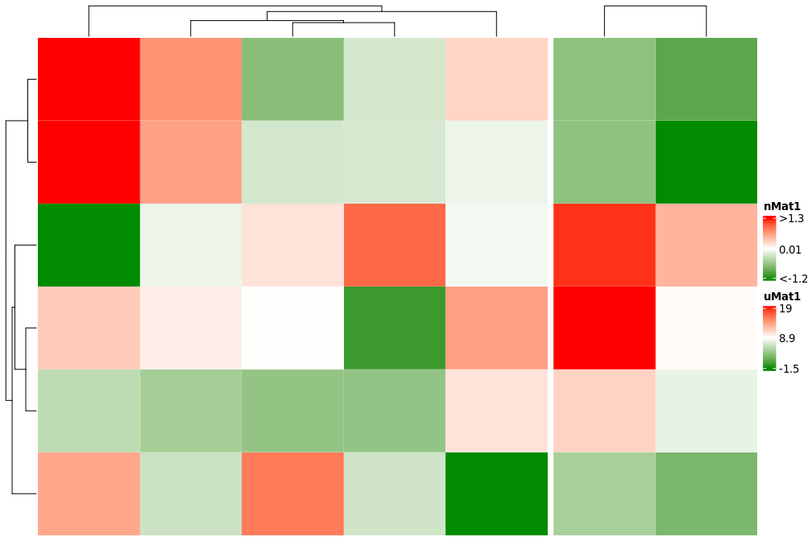

```r
nMat1 <- matrix(rnorm(30), nrow = 6)
uMat1 <- matrix(runif(12, -5, 20), nrow = 6)

hm1 <- cHeatmap(nMat1, drawHeatmap = F, name = "nMat1")
hm2 <- cHeatmap(uMat1, drawHeatmap = F, name = "uMat1")
hm1 + hm2
```

### Plot inside each row using `rowDraw`

Here `painScore` of `patient 2` is plotted across visits. Its values are transformed to the range of (0,1), representing relative values across visits.

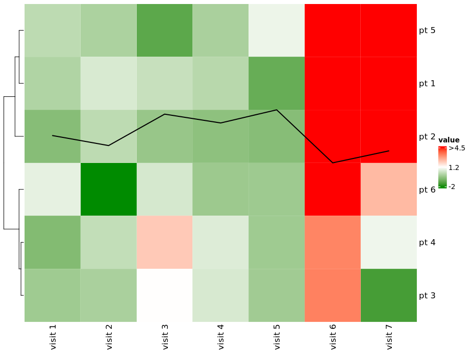

```r
mat1 <- matrix(c(nMat1, uMat1), nrow = 6)
rownames(mat1) <- paste("pt", 1:6)
colnames(mat1) <- paste("visit", 1:7)

painScore <- rnorm(7)

cHeatmap(mat1,
  name = "value", cluster_columns = F,
  rowDraw = list(
    list("grid.lines", col = "black", lwd = 2),
    matrix(painScore, nrow = 1), # data to be plotted
    2 # plot at the 2nd row of mat1
  )
)
```

Plot both lines and points in multiple rows.

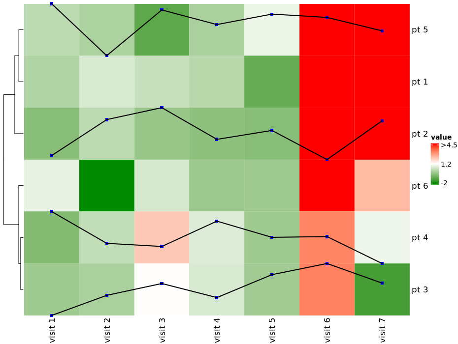

```r
# longitudinal scores of four patients
painScore <- matrix(rnorm(28), nrow = 4)
cHeatmap(mat1,
  name = "value", cluster_columns = F,
  rowDraw = list(
    list(
      list("grid.points", size = 0.5, pch = 15, col = "blue"),
      list("grid.lines", col = "black", lwd = 2)
    ),
    painScore,
    c(2, 3, 4, 5) # row indices of the four patients in mat1
  )
)
```